Skip to contents

# 💾 FAO data: download and customise

Source: [`vignettes/articles/data.Rmd`](https://github.com/Linbojun99/faofishingreport/blob/main/vignettes/articles/data.Rmd)

📦 **Data**: [FAO Global Capture Production](https://www.fao.org/fishery/collection/capture/en), release **2026.1.0** (published by FAO on 2026-03-30; catches 1950–2024), downloaded from Capture_2026.1.0.zip. Licence [CC BY 4.0](https://creativecommons.org/licenses/by/4.0/). `fao_data_info()` shows the release you use and how to cite it.

## 📚 The data

faofishingreport uses the **FAO Global Capture Production** statistics: the yearly catch of every country, by species item and FAO major fishing area, since 1950. Only capture fisheries are included (no aquaculture), in tonnes live weight. FAO compiles them from the reports of national offices and estimates the catch of countries that did not report (FAO 2026; Garibaldi 2012).

```r
data <- load_fao_data()
c(rows = nrow(data), first_year = min(data$Year), last_year = max(data$Year),
  countries = length(unique(data$Country..Name.)),
  species = length(unique(data$ASFIS.species..Name.)),
  areas = length(unique(data$FAO.major.fishing.area..Name.)))
```

```
#>       rows first_year  last_year  countries    species      areas
#>    1024698       1950       2024        248       3797         26
```

FAO publishes a new release about once a year, adding one more year and revising earlier years. The package comes with a recent release, and can download newer ones directly from the [FAO statistics server](https://www.fao.org/fishery/static/Data/), where each release is a file `Capture_<version>.zip`.

The functions of this page:

| Function | What it does |
| --- | --- |
| `check_fao_update()` | Lists the releases on the FAO server and compares the newest with the data on your computer |
| `download_fao_data()` | Downloads a release and converts it to the package format |
| `load_fao_data()` | Loads a downloaded release or the bundled data |
| `fao_data_info()` | The release used, its download link, licence and citation |
| `fao_data_dir()` | The folder where downloaded releases are kept |
| `fao_translate()` | Chinese and bilingual names of countries, species and areas |

## 🔎 Check for a new release

`check_fao_update()` lists the releases on the FAO server and compares the newest with the data bundled with the package and the data you have downloaded:

```r
check_fao_update()
```

```
#> FAO Global Capture Production
#>   Latest online release: 2026.1.0 (published 2026-03-30)
#>   Bundled with package:  2026.1.0
#>   Downloaded locally:    none
#>   Your data is up to date.
```

| Argument | Meaning | Default |
| --- | --- | --- |
| `data_dir` | Folder where downloaded releases are stored | `fao_data_dir()` |
| `quiet` | `TRUE` prints nothing, e.g. in scripts | `FALSE` |

It also returns, invisibly, a list:

| Element | Content |
| --- | --- |
| `latest` | Newest release online |
| `bundled` | Release bundled with the package |
| `local` | Newest downloaded release (`NA` if none) |
| `update_available` | `TRUE` if the newest online release is newer than the bundled and downloaded data |
| `releases` | All releases online: `version`, publication `date`, `size` and download `url` |

```r
releases <- check_fao_update(quiet = TRUE)
releases$update_available
```

```
#> [1] FALSE
```

```r
tail(releases$releases, 3)
```

```
#>     version       date size                                                          url
#> 9  2024.1.0 2024-04-04 4.5M https://www.fao.org/fishery/static/Data/Capture_2024.1.0.zip
#> 10 2025.1.0 2025-09-04 5.0M https://www.fao.org/fishery/static/Data/Capture_2025.1.0.zip
#> 11 2026.1.0 2026-03-30 5.5M https://www.fao.org/fishery/static/Data/Capture_2026.1.0.zip
```

## ⬇️ Download a release

`download_fao_data()` downloads a release (about 5 MB), converts it to the package format and saves it on your computer. Downloading again is not needed: later calls read the saved file.

```r
download_fao_data()                       # the latest release
download_fao_data(version = "2023.1.1")   # an older release, e.g. to reproduce a report
download_fao_data(overwrite = TRUE)       # download again
```

| Argument | Meaning | Default |
| --- | --- | --- |
| `version` | Release to download, e.g. `"2026.1.0"`, or `"latest"` for the newest release online. A release that is not on the FAO server gives an error listing the available ones | `"latest"` |
| `data_dir` | Folder where the release is saved | `fao_data_dir()` |
| `overwrite` | `FALSE` reads a release that was already downloaded from disk; `TRUE` downloads it again | `FALSE` |
| `quiet` | Hide the progress messages | `FALSE` |

It returns the data invisibly. The conversion keeps the quantities in tonnes live weight, matches countries and species through their FAO codes to the names used by the package, and records the release, its publication date, the download link and the download date (`attr(data, "fao_version")`, `attr(data, "release_date")`, `attr(data, "source_url")`, `attr(data, "download_date")`). Each release is saved as three files:

| File | Content |
| --- | --- |
| `Global_Production_long_<version>.rds` | The catch data |
| `fao_names_<version>.rds` | Official Chinese names of countries, species and areas |
| `fao_groups_<version>.rds` | Species groups (ISSCAAP, taxonomic level), country groups and area groups |

### 📂 Choose the data folder

`fao_data_dir()` has no arguments; it returns the folder where `download_fao_data()` (and `download_fishbase_data()`) save data and where all functions look for them. It is the first of:

| Order | Source | Set with |
| --- | --- | --- |
| 1 | The `data_dir` setting | `fao_settings(data_dir = "D:/shared/fao_data")` (this R session) |
| 2 | The environment variable `FAOFISHINGREPORT_DATA_DIR` | A line `FAOFISHINGREPORT_DATA_DIR=<folder>` in the `.Renviron` file of your home folder (every R session) |
| 3 | The user data folder of R, `tools::R_user_dir("faofishingreport", "data")` | Default |

```r
fao_data_dir()
```

```
#> [1] "C:/Users/<you>/AppData/Roaming/R/data/R/faofishingreport"          # Windows
#> [1] "~/Library/Application Support/org.R-project.R/R/faofishingreport"  # macOS
#> [1] "~/.local/share/R/faofishingreport"                                 # Linux
```

To keep the data elsewhere, for example in a folder shared by your team, set `data_dir` once. Downloads then go there, and every function reads from there:

```r
fao_settings(data_dir = "D:/shared/fao_data")
download_fao_data()
```

## 🧭 Which release is used

All functions use the **newest** data available: the newest downloaded release, or the bundled data if it is newer. `fishing_area_data()`, `country_analysis()` and `fao_report()` can be told which release to use with `data_version`:

```r
FAO27 <- fishing_area_data("Atlantic, Northeast")                            # newest
FAO27 <- fishing_area_data("Atlantic, Northeast", data_version = "bundled")  # bundled
FAO27 <- fishing_area_data("Atlantic, Northeast", data_version = "2023.1.1") # a download
```

`load_fao_data()` returns the whole data set, with the same choices:

```r
data <- load_fao_data()                  # newest
data <- load_fao_data("2023.1.1")        # a downloaded release
```

[output not shown]

It returns a data frame with the eight columns described below, and prints which release it loaded.

### 📝 Release information and citation

`fao_data_info()` tells which release the analyses use, when FAO published it, the years it covers, the file it was downloaded from, the licence and a citation for reports. It has the same arguments as `load_fao_data()` (`version`, default `"latest"`, and `data_dir`, default `fao_data_dir()`):

```r
fao_data_info()
```

```
#> FAO Global Capture Production
#>   Release:   2026.1.0 (published by FAO on 2026-03-30)
#>   Years:     1950-2024
#>   File:      https://www.fao.org/fishery/static/Data/Capture_2026.1.0.zip
#>   Obtained:  bundled with faofishingreport, downloaded from FAO on 2026-10-10
#>   Licence:   CC BY 4.0 (https://www.fao.org/contact-us/terms/db-terms-of-use/en)
#>   Citation:  FAO. 2026. Global Capture Production 1950-2024, release 2026.1.0. In: Fisheries and Aquaculture [online]. Rome. [Cited 10 October 2026]. https://www.fao.org/fishery/collection/capture/en. Licence: CC BY 4.0.
```

```r
fao_data_info()$citation           # the citation only
fao_data_info("2025.1.0")          # a downloaded release
```

It returns a list:

| Element | Content |
| --- | --- |
| `release` | The release, e.g. `"2026.1.0"` |
| `release_date` | Date of publication on the FAO server |
| `years` | First and last year of the data |
| `source` | `"bundled"` (with the package) or `"downloaded"` |
| `url` | The release file on the FAO server |
| `download_date` | Date the data was downloaded from FAO |
| `licence`, `terms` | `"CC BY 4.0"` and the FAO terms of use of statistical databases |
| `citation` | A citation of the release for reports |

## 📋 Data format

Every release is converted to the same eight columns, so all analyses work with any release:

```r
show_table(data, n = 6)
```

| Country..Name. | ASFIS.species..Name. | FAO.major.fishing.area..Name. | Unit..Name. | Unit | Year | Production | Production.Type |
| --- | --- | --- | --- | --- | --- | --- | --- |
| Afghanistan | Freshwater fishes nei | Asia - Inland waters | Tonnes - live weight | TLW, Number | 1950 | 100 | actual |
| Afghanistan | Freshwater fishes nei | Asia - Inland waters | Tonnes - live weight | TLW, Number | 1951 | 100 | actual |
| Afghanistan | Freshwater fishes nei | Asia - Inland waters | Tonnes - live weight | TLW, Number | 1952 | 100 | actual |
| Afghanistan | Freshwater fishes nei | Asia - Inland waters | Tonnes - live weight | TLW, Number | 1953 | 100 | actual |
| Afghanistan | Freshwater fishes nei | Asia - Inland waters | Tonnes - live weight | TLW, Number | 1954 | 100 | actual |
| Afghanistan | Freshwater fishes nei | Asia - Inland waters | Tonnes - live weight | TLW, Number | 1955 | 200 | actual |

| Column | Content |
| --- | --- |
| `Country..Name.` | Country (FAO short name, e.g. “Korea, Republic of”) |
| `ASFIS.species..Name.` | Species item (ASFIS English name; items not identified to species end in “nei”) |
| `FAO.major.fishing.area..Name.` | FAO major fishing area |
| `Unit..Name.`, `Unit` | Always tonnes live weight |
| `Year` | Year |
| `Production` | Catch in tonnes |
| `Production.Type` | Status of the value, from the FAO status flag: `actual` (official), `estimate` (estimated by the country or FAO), `neligible` (below 0.5 t), `provisional`, `suppressed`, `international organization` |

## ✂️ Analyse your own subsets

The analysis functions take a data frame with these columns, so any subset can be analysed. `fishing_area_data()` is the easiest way to get one fishing area, but you can also build subsets yourself:

```r
# The catch of several fishing areas together, e.g. the whole Atlantic
atlantic <- subset(data, grepl("^Atlantic", FAO.major.fishing.area..Name.))
unique(atlantic$FAO.major.fishing.area..Name.)
```

```
#> [1] "Atlantic, Southeast"       "Atlantic, Eastern Central"
#> [3] "Atlantic, Western Central" "Atlantic, Southwest"
#> [5] "Atlantic, Antarctic"       "Atlantic, Northeast"
#> [7] "Atlantic, Northwest"
```

```r
# The species groups of the whole Atlantic since 2000
species_group_composition(subset(atlantic, Year >= 2000), label = "Atlantic since 2000")
```

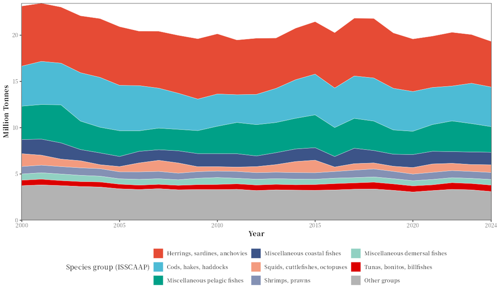

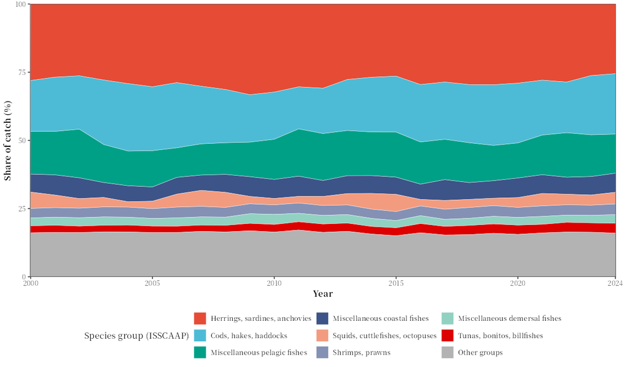

The summary analyses, such as `species_group_composition()` and `peak_trend()`, share these arguments (their own arguments are described in 📈 Composition, stock status and trends):

| Argument | Meaning | Default |
| --- | --- | --- |
| `area_data` | The catch data: `fishing_area_data()$area_data` or any subset of `load_fao_data()` |  |
| `plot` | Save the charts in `figures/png/summary/` | `TRUE` |
| `table` | Save the tables in `tables/` | `TRUE` |
| `lang` | `"en"`, `"zh"` or `"both"` | `NULL`: the language of `fao_settings()` |
| `pptx` | Also save editable PowerPoint files in `figures/pptx/summary/` | `FALSE`, or `pptx` of `fao_settings()` |
| `plot_show` | Also draw each chart in the plot window (e.g. the Plots pane of RStudio) as it is saved | `FALSE`, or `plot_show` of `fao_settings()` |
| `label` | Name used in the output file names | `NULL`: the fishing area (or country) of the data |

More examples:

```r
# One country in all areas
china <- subset(data, Country..Name. == "China")
peak_trend(china, by = "area", label = "China")

# One species in all areas
skipjack <- subset(data, ASFIS.species..Name. == "Skipjack tuna")
peak_trend(skipjack, by = "area", label = "Skipjack tuna")

# Only the last 30 years of area 27
FAO27_recent <- subset(FAO27$area_data, Year >= 1995)
fishing_area_species(FAO27_recent)
```

To find the exact names of countries, species and areas:

```r
head(sort(unique(data$Country..Name.)), 10)
```

```
#>  [1] "Afghanistan"         "Albania"             "Algeria"
#>  [4] "American Samoa"      "Andorra"             "Angola"
#>  [7] "Anguilla"            "Antigua and Barbuda" "Argentina"
#> [10] "Armenia"
```

```r
grep("tuna", unique(data$ASFIS.species..Name.), value = TRUE)
```

```
#>  [1] "Atlantic bluefin tuna"    "Frigate and bullet tunas"
#>  [3] "Bullet tuna"              "Skipjack tuna"
#>  [5] "Yellowfin tuna"           "Dogtooth tuna"
#>  [7] "Bigeye tuna"              "Pacific bluefin tuna"
#>  [9] "Southern bluefin tuna"    "Longtail tuna"
#> [11] "Frigate tuna"             "True tunas nei"
#> [13] "Blackfin tuna"            "Slender tuna"
```

## 🌐 Chinese names

Chinese names come from the FAO code lists published with each release and from the FAO ASFIS species list; names without an official Chinese name are filled from the package’s own tables, and otherwise stay in English. `fao_translate()` shows them:

```r
fao_translate(c("Norway", "Spain", "Korea, Republic of"), "country", "zh")
```

```
#> [1] "挪威"     "西班牙"   "大韩民国"
```

```r
fao_translate(c("Atlantic cod", "Skipjack tuna"), "species", "both")
```

```
#> [1] "大西洋鳕 Atlantic cod" "鲣 Skipjack tuna"
```

```r
fao_translate("Atlantic, Northeast", "area", "zh")
```

```
#> [1] "东北大西洋"
```

| Argument | Meaning | Default |
| --- | --- | --- |
| `x` | English names, as in the FAO data |  |
| `type` | Kind of name: `"country"`, `"species"` or `"area"` | `"country"` |
| `lang` | `"zh"` (Chinese), `"both"` (Chinese and English) or `"en"` (unchanged) | `"zh"` |

It returns the names in the same order. Different English names that share one Chinese name keep their English name as well (e.g. two species items with the same Chinese name), so they stay apart in charts and tables.

Many species items have no Chinese name in the FAO lists. For the items that are one species, the package uses the Chinese common name of the species in [FishBase](https://www.fishbase.se) or [SeaLifeBase](https://www.sealifebase.se): the name given for China, in simplified characters, preferring the name FishBase marks as preferred (Froese and Pauly 2026; Palomares and Pauly 2026). FAO names always come first. The table, with the other names of each species and their source, is `inst/extdata/species_names_zh_fishbase.csv`, made by `data-raw/build_species_names_zh.R` from the FishBase tables that the rfishbase package reads:

```r
fao_translate(c("Pacific cod", "Yellowfin sole", "Pacific ocean perch"), "species", "zh")
```

```
#> [1] "太平洋鳕"            "糙鲽"                "Pacific ocean perch"
```

The Pacific ocean perch keeps its English name: FishBase has no simplified Chinese name for China for it.

FAO gives no Chinese names for ISSCAAP species groups, major groups and income groups; the package’s translations are in `inst/extdata/group_names_zh.csv`, and all chart labels in `inst/extdata/chart_labels.csv`. Edit these files in the package source and reinstall to change the wording.

## 🧩 Extension: catch by division

This and the next section use FAO datasets other than global capture production; they are an extension of the package and not part of the Word report.

For four regions FAO also publishes the catch by **division**, the parts of an FAO area used by regional fishery bodies: GFCM (area 37, e.g. 37.1.1 Balearic, 37.2.1 Adriatic, 37.4.2 Black Sea), CECAF (area 34), the Southeast Atlantic (area 47) and RECOFI (the Gulf, the Sea of Oman and the southwestern Arabian Sea, part of area 51). `load_fao_divisions()` downloads the newest release the first time (about 5 MB), keeps it in the data folder, and returns it in the format above with three more columns: `Division`, `Division..Name.` and `Region`.

```r
med <- load_fao_divisions("GFCM")
pelagic_demersal(med, by = "division")          # one P/D series per division
mean_temperature_catch(med, by = "division")    # MTC and SST of each division
```

For GFCM, CECAF and the Southeast Atlantic, the catch summed over the divisions equals that of the FAO area for nearly all records. Some codes are not places: “37.0.0 Tunas” holds tunas reported for the whole area and “37.9.0 Not known” catch whose division is not known.

## 🧩 Extension: trade and employment data

FAO also publishes the trade of aquatic products and the employment in fisheries and aquaculture. `load_fao_trade()` (exports, imports and re-exports by country, commodity and year from 1976, about 16 MB) and `load_fao_employment()` (people by country, work area, working time and sex from 1995, under 1 MB) download them the first time and keep them in the data folder, like `load_fao_divisions()`. Trade quantities are product weight, not live weight, and employment counts people, not full-time equivalents. See 🚢 Trade and employment for the analyses that join them to the catch: `catch_trade()`, `employment_summary()` and `catch_per_fisher()`.

```r
trade <- load_fao_trade()
employment <- load_fao_employment()
```

## ⚠️ Notes on the data

- **Recent years are often estimated.** When a country has not yet reported, FAO estimates its catch. In area 34 (Eastern Central Atlantic), about a third of the 2024 catch is estimated, against less than 1% in area 27; these values are usually revised in the next release. `data_quality()` shows this for any area.
- **“nei” items** (“not elsewhere included”) are catches not identified to species, e.g. “Marine fishes nei”. They are a large share of the catch in some areas.
- **Former countries** such as the USSR (until 1991) appear as separate countries.
- **Releases differ**: FAO revises past years when countries send corrected or more complete data (Garibaldi 2012; Zeller and Pauly 2018), so results from different releases can differ. Note the release used in reports (`fao_data_info()`). `compare_releases()` lists the records revised between two releases (see 🔬 Shocks, collapses, synchrony and fleets).
- **Use of the data**: the FAO statistics are published under the CC BY 4.0 licence and the FAO terms of use of statistical databases; cite the release you use.

## 🔄 For maintainers: update the bundled data

The bundled data, Chinese names and groups are rebuilt from the latest FAO release with:

```bash
Rscript data-raw/update_bundled_data.R
```

## 📖 References

CWP (Coordinating Working Party on Fishery Statistics). *CWP Handbook of Fishery Statistics*. Rome: FAO. https://www.fao.org/cwp-on-fishery-statistics/handbook/en/

FAO (2026). FishStat: Global capture production 1950–2024 (release 2026.1.0). In: FishStatJ. https://www.fao.org/fishery/statistics/software/fishstatj/en. Licence: CC-BY-4.0. Release file: https://www.fao.org/fishery/static/Data/Capture_2026.1.0.zip; all releases: https://www.fao.org/fishery/static/Data/

FAO (2026). *Fishery and Aquaculture Statistics – Yearbook 2024*. FAO Yearbook of Fishery and Aquaculture Statistics. Rome: FAO. [doi:10.4060/ce1217en](https://doi.org/10.4060/ce1217en)

FAO. *ASFIS List of Species for Fishery Statistics Purposes*. Rome: FAO. https://www.fao.org/fishery/collection/asfis/en

FAO. *Global Capture Production*. Fisheries and Aquaculture Division, Rome. https://www.fao.org/fishery/collection/capture/en

FAO. *Terms of use of FAO statistical databases*. https://www.fao.org/contact-us/terms/db-terms-of-use/en

Froese, R. and Pauly, D. (Eds.) (2026). FishBase. World Wide Web electronic publication, version 06/2026. https://www.fishbase.se

Garibaldi, L. (2012). The FAO global capture production database: a six-decade effort to catch the trend. *Marine Policy* 36(3): 760–768. [doi:10.1016/j.marpol.2011.10.024](https://doi.org/10.1016/j.marpol.2011.10.024)

Palomares, M. L. D. and Pauly, D. (Eds.) (2026). SeaLifeBase. World Wide Web electronic publication, version 06/2026. https://www.sealifebase.se

Zeller, D. and Pauly, D. (2018). The ‘presentist bias’ in time-series data: implications for fisheries science and policy. *Marine Policy* 90: 14–19. [doi:10.1016/j.marpol.2018.01.015](https://doi.org/10.1016/j.marpol.2018.01.015)